# Kremer_hmwrk2_wrangling_data

Lauren Kremer

2/4/2022

**Opening the data**  
Generate a function that:

1. opens all files in the data folder and
2. adds the index name as a column value to the dataframe
3. concatonates the data into one df

```r
opn_concat_co <- function(data_folder) {
  path_list <- paste(getwd(),list.files(data_folder, full.names = T), sep='/')
  data <- lapply(path_list, function(x) {
    dat <- read.csv(x)%>%
    rename(burned=2,unburned=3) %>%
    mutate(data = strsplit(strsplit(strsplit(x, "/")[[1]][9], '_')[[1]][2], '\\.')[[1]][1])
    return(dat)
  })
  combined.data <- do.call(rbind, data)
  return(combined.data)
}
```

Open the data for the assingment:

```r
# Open as a long dataset
full_long <- opn_concat_co('data') %>%
  gather(key='site',value='value',-DateTime,-data) %>%
  filter(!is.na(value))
```

**Question 1**

1. What is the correlation between NDVI and NDMI? - here I want you to convert the full_long dataset in to a wide dataset using the function “spread” and then make a plot that shows the correlation as a function of if the site was burned or not

-Using spread(), convert long dataset into wide  
-remove rows with NA vaues  
-add a ‘month’ and ‘year’ column for aggregation

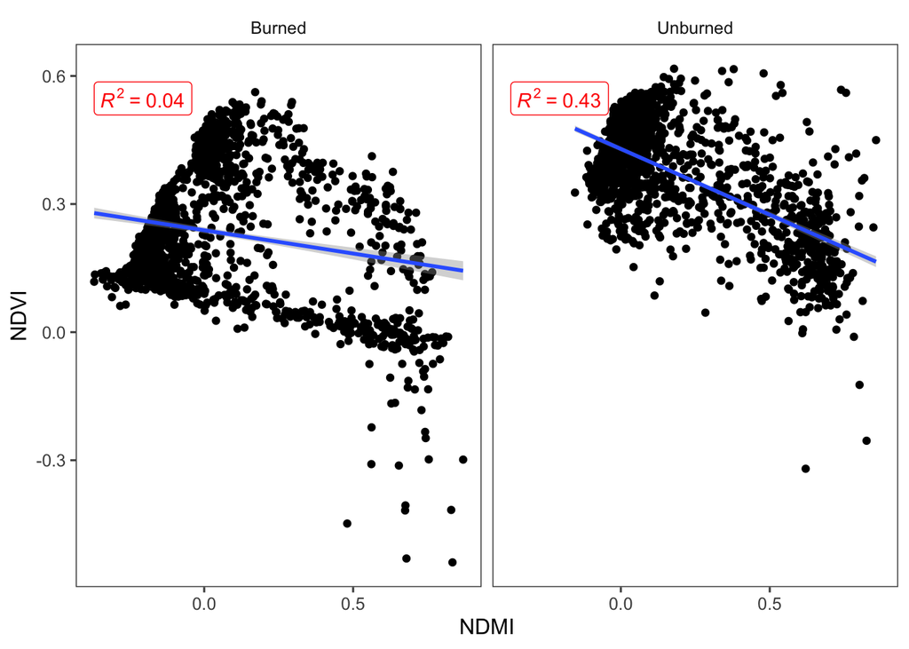

```r
full_wide <- spread(data=full_long, key='data',value='value') %>%
  filter_if(is.numeric,all_vars(!is.na(.))) %>%
  mutate(month = month(DateTime),
         year = year(DateTime))

site_names <- c('burned' = "Burned",
                'unburned' = "Unburned") # using this as a labeller for the
# facet wrap
ggplot(full_wide,aes(x=ndmi,y=ndvi)) +
  geom_point() +
  geom_smooth(method='lm', formula= y~x) +
  facet_wrap(~site, labeller = as_labeller(site_names)) +
  stat_cor(aes(label = ..rr.label..), color = "red", geom = "label") +
  theme_few() +
  xlab("NDMI") +
  ylab("NDVI") +
  scale_color_few(palette = 'Dark') +
  theme(legend.position=c(0.8,0.8))
```

**Response**  
**It appears as though there is a greater correlation between NDVI and NDMI in unburned plots than burned plots, though there is a lot of variability. There may be some winter points (e.g. high NDMI, low NDVI) that indicate winter observations could be removed to make relationships more clear.**

**Question 2** What is the correlation between average NDSI (normalized snow index) for January - April and average NDVI for June-August? In other words, does the previous year’s snow cover influence vegetation growth for the following summer?

Using the wide dataframe to keep month column,  
-select needed columns,  
-make dataframe long for easy filtering and plotting  
-filter the dataframe with an ‘or’, keeping everthing with NDSI month %in% c(1,2,3,4), NDVI month %in% c(6,7,8)  
-average NDVI and NDSI values by year  
-spread the data to plot NDVI vs. NDSI

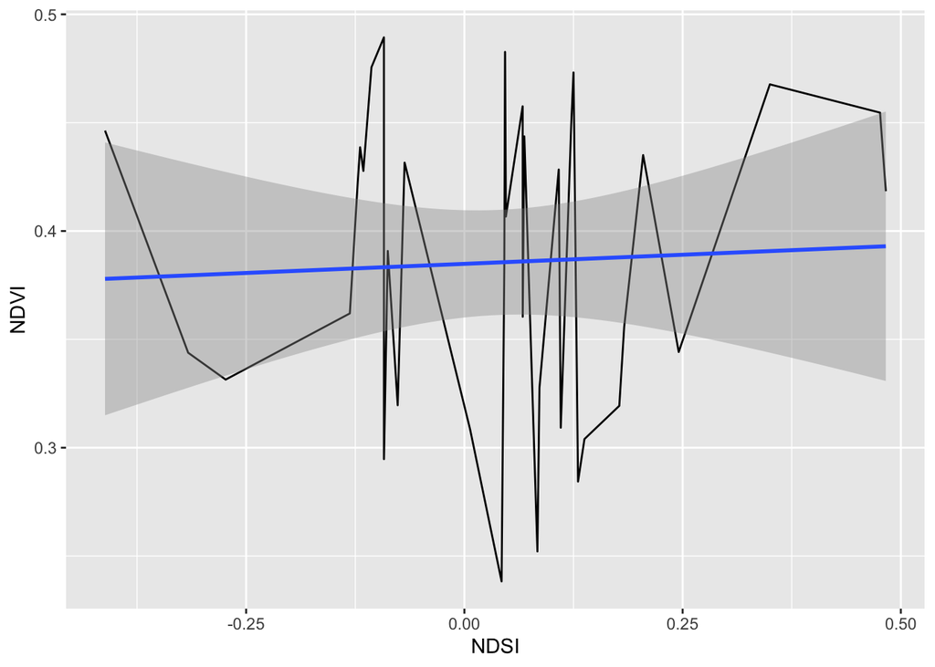

```r
plot_data <- full_wide %>%
  select(c(month, year, ndvi, ndsi)) %>%
  pivot_longer(c(ndvi,ndsi)) %>%
  filter(name == 'ndvi' & month %in% c(6,7,8) | name== 'ndsi' & month %in% c(1,2,3,4)) %>%
  group_by(year, name) %>% summarize(meanvalue = mean(value)) %>%
  spread(key='name', value='meanvalue')

#create line plot for yearly mean...
ggplot(plot_data, aes(ndsi, ndvi)) +
  geom_line() +
  geom_smooth(method='lm', formula= y~x) +
  xlab('NDSI') +
  ylab('NDVI')
```

**Response**  
**There does not appear to be a correlation between NDSI and NDVI at these sites. However, the indices each reflect a lot of annual variability even with the limited months.It would be interesting to see the effect of temperature on this data.**

**Question 3** How is the snow effect from question 2 different between pre- and post-burn and burned and unburned?

Organization and aggregation methods are the same as for Question 2 but with the additon of ‘site’ in group by() to separate burned and unburned values.

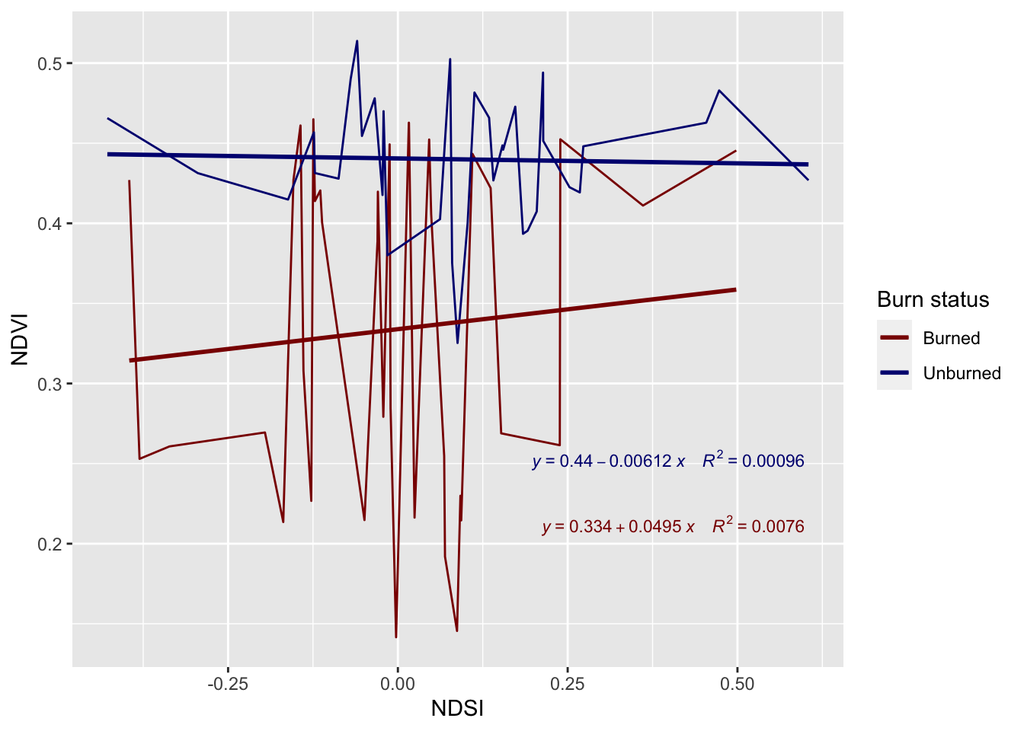

```r
plot_data_fire <- full_wide %>%
  select(c(month, year, ndvi, ndsi, site)) %>%
  pivot_longer(c(ndvi,ndsi)) %>%
  filter(name == 'ndvi' & month %in% c(6,7,8) | name== 'ndsi' & month %in% c(1,2,3,4)) %>%
  group_by(year, name, site) %>% summarize(meanvalue = mean(value)) %>%
  spread(key='name', value='meanvalue')

#create line plot for yearly mean...

ggplot(plot_data_fire, aes(ndsi, ndvi, color = site)) +
  geom_line() +
  geom_smooth(method='lm', formula= y~x, se = F) +
  xlab('NDSI') +
  ylab('NDVI') +
  scale_color_manual(name="Burn status",
                       labels=c("Burned","Unburned"),
                       values=c("darkred", "navy")) +
                       stat_poly_eq(aes(label = paste(..eq.label.., ..rr.label.., sep = "~~~~")),
               label.x.npc = "right", label.y.npc = c(0.2, 0.3),
               formula = y~x, parse = TRUE, size = 3)
```

**Response**  
**Separating burned from unburned reveals that there may be a greater correlation between NDSI and NDVI in burned sites, but the r2 value is very low. Again, interannual variation could be affecting this so the addition of more variables might reveal that a combination of, say, NDSI and spring temperatures affect NDVI**

**Question 4** What month is the greenest month on average? Does this change in the burned plots after the fire?

```r
# To simply print max monthly values for each burn type:
max_ndvi <- full_wide %>%
  select(c(month, year, ndvi, site)) %>% # select desired columns
  group_by(month, site) %>% # group by month and burn type
  summarize(value = mean(ndvi)) %>% #find the mean
  ungroup()%>%
  group_by(site) %>% # group again by burn type
  filter(value == max(value)) # and find the max value for each

max_ndvi
```

```
## # A tibble: 2 x 3
## # Groups:   site [2]
##   month site     value
##   <dbl> <chr>    <dbl>
## 1     8 burned   0.322
## 2     9 unburned 0.459
```

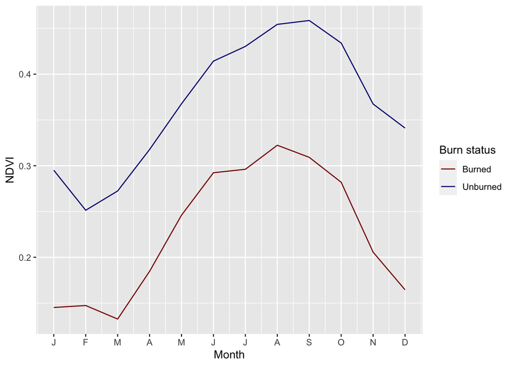

```r
# Or we can look at plots to determine max visually

plot_data_ndvi <- full_wide %>%
  select(c(month, year, ndvi, site)) %>%
  group_by(month, site) %>% summarize(meanvalue = mean(ndvi))


# generate a plot that compares burned with unburned
ggplot(plot_data_ndvi, aes(month, meanvalue, color = site)) +
  geom_line() +
  xlab('Month') +
  ylab('NDVI') +
  scale_x_continuous(breaks = 1:12,
                     labels = c('J', 'F', 'M', 'A', 'M', 'J', 'J', 'A', 'S', 'O', 'N', 'D')) +
  scale_color_manual(name="Burn status",
                       labels=c("Burned","Unburned"),
                       values=c("darkred", "navy"))
```

**Response**  
**The greenest month appears to be August for the burned plots and September for the unburned plots.**

**Question 5** What month is the snowiest on average?

```r
# To simply print max monthly values, use same code as above :
max_ndsi <- full_wide %>%
  select(c(month, year, ndsi)) %>%
  group_by(month) %>%
  summarize(value = mean(ndsi)) %>%
  filter(value == max(value))

max_ndsi
```

```
## # A tibble: 1 x 2
##   month value
##   <dbl> <dbl>
## 1     1 0.210
```

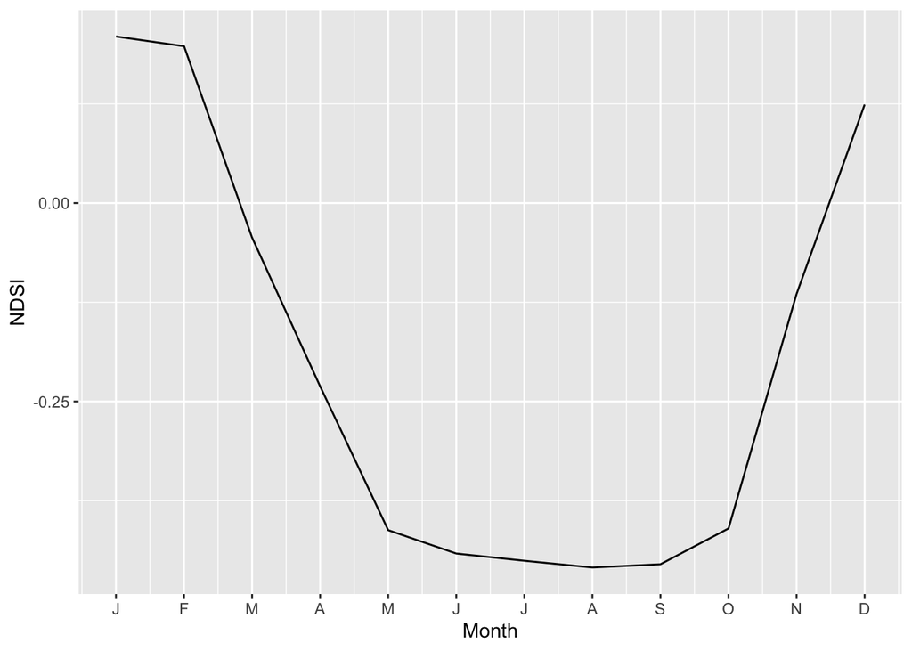

```r
# January appears to have maximum monthly mean
# Or we can look at plots to determine max visually

plot_data_ndsi <- full_wide %>%
  select(c(month, year, ndsi)) %>%
  group_by(month) %>% summarize(meanvalue = mean(ndsi))


# generate a plot that compares burned with unburned
ggplot(plot_data_ndsi, aes(month, meanvalue)) +
  geom_line() +
  xlab('Month') +
  ylab('NDSI') +
  scale_x_continuous(breaks = 1:12,
                     labels = c('J', 'F', 'M', 'A', 'M', 'J', 'J', 'A', 'S', 'O', 'N', 'D'))
```

**Response**  
**January appears to have the highest monthly mean**